# Finding phylogenies

Example with Liolaemus.csv is a student file with CTmin and CTmax data

The student wants to measure a phylogenetic signal using Blomberg’s K

# Obtaining trees

## Option 1 - Find published phylogeny (= best solution)

It is well worth conducting a literature search. For example, using *GoogleScholar* and searching for “liolaemus phylogeny” I have found a number of useful looking papers (including: [Evolution of Thermal Physiology in Liolaemus Lizards: Adaptation, Phylogenetic Inertia, and Niche Tracking](https://www.journals.uchicago.edu/doi/abs/10.1086/600088?casa_token=3xhoa-OsRQgAAAAA:A98eoi4qF6upGpP1nV-4jY17oJuLvmJg44p5y-Yg8gf1a4ctcy5HA3RGetJtXOwxDZN75MMEqUnNGQ)). It would also be worth doing a formal search using [Web of Science](https://search.library.uq.edu.au/primo-explore/fulldisplay?docid=61UQ_ALMA61117021610003131&vid=61UQ&search_scope=61UQ_All&tab=61uq_all&lang=en_US&context=L).

Should you find a paper with an appropriate phylogenetic tree, try looking in supplementary data for a tree file. They might have saved it on Treebase or Figshare. Feel free to post a question with the paper pdf on the discussion board.

## Option 2 - Get relevant tree from Open Tree of Life (= next best)

Open Tree of Life compiles phylogenies and where phylogenetic information is missing, will amalgamate with taxonomy to make a pseudo-tree.

See [r Open Tree of Life Vignette](https://cran.r-project.org/web/packages/rotl/vignettes/rotl.html). # Note that rotl works fine on the UQ Digital workspace but sometimes not on personal computers

```r
install.packages("rotl")  #access open tree of life data
install.packages("ape")  #useful for tree manipulations
```

```r
library(rotl)
library(ape)
```

### OTL Strategy A: grab full tree of genus and save to file

```r
taxon <- "Liolaemus"   #the genus that we are focusing on - use highest taxonomic level to get root and all descendents

resolved_names <- tnrs_match_names(taxon)   #pulls out the otl name for the defining root node
# if you get a SSL error, run this on UQ computer

Liolaemus_tree <- tol_subtree(ott_id = ott_id(resolved_names))  #pulls out the subtree defined by your nodes
#ignore warnings about singletons

plot(Liolaemus_tree)
# it will be messy!

write.tree(Liolaemus_tree, file="Liolaemus_tree.new", digits = 10)
```

### OTL Strategy B: make a tree of just your species

```r
phys_data<-read.csv("Liolaemus.csv", header= 1) #read in our data file
names(phys_data)<-c("species", "CTmin", "CTmax")  #something odd happening with names, so rewrite

species<-phys_data$species #define list of species
taxa <- tnrs_match_names(species, context = "Animals")  #look for matches in OTL
#note error -> might want to check info for this species - could be dropped.

focal_tree <- tol_induced_subtree(ott_id(taxa))
plot(focal_tree)

write.tree(focal_tree, file="Liolaemus_focal_tree.new", digits = 10)
```

## Option 3 - Make a taxonomy only tree with phyloT

Go to [phyloT](https://phylot.biobyte.de) and paste your species names. Using our **Liolaemus** examples, I got an error for **Liolaemus extrilidus** so removed that for now (maybe the species name is misspelled or there is a synonym?); the rest of the names yielded a tree (save a Newick format).

## Option 4 - Make your own tree from DNA sequences

See `Making_a_Custom_Phylogenetic_Tree.docx`

# Examining and manipulating the trees

If you did not already look at the two otl trees, you can import and look at them and compare them to the taxonomy only tree from phyloT.

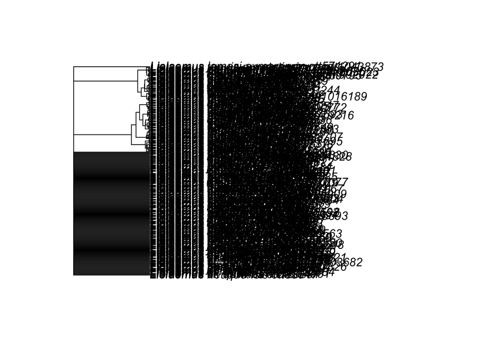

```r
Liolaemus_tree<-read.tree("Liolaemus_tree.new") # alll Liolaemus from otl
plot(Liolaemus_tree)  #very messy, too many taxa
```

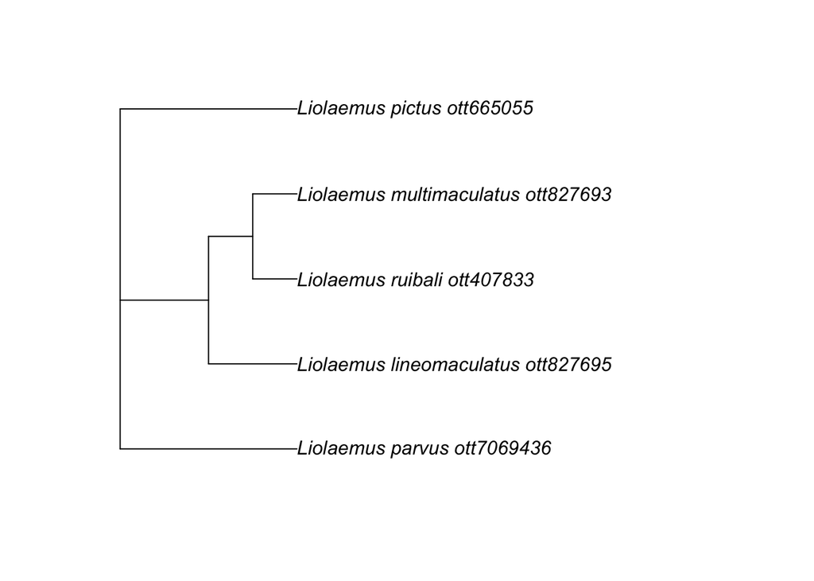

```r
focal_tree<-read.tree("Liolaemus_focal_tree.new")
plot(focal_tree) #look ok for now
```

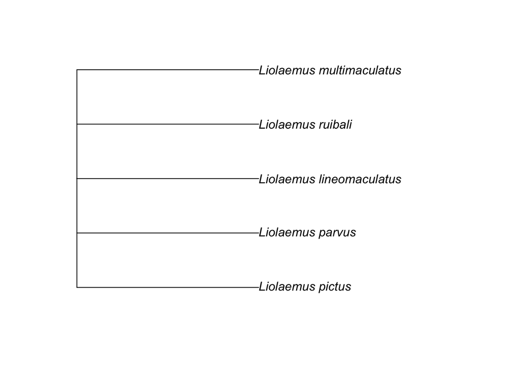

```r
taxonomy_tree<-read.tree("phyloT_generated_tree_newick.txt")
plot(taxonomy_tree) #unresolved polytomy
```

All three of these trees have some issues that will need to dealt with before any sort of phylogenetic analysis can be conducted.

## Removing extra taxa

```r
#what taxa are in the Liolaemus_tree?
Liolaemus_tree$tip.label
```

```
##   [1] "Liolaemus_neuquensis_ott83947"
##   [2] "Liolaemus_cf._quilmes_1_ott114981"
##   [3] "Liolaemus_cf._darwinii_ott120381"
##   [4] "Liolaemus_cf._boulengeri_ott120384"
##   [5] "Liolaemus_cf._rothi_ott120385"
##   [6] "Liolaemus_cf._quilmes_ott120389"
##   [7] "Liolaemus_avilai_ott276948"
##   [8] "Liolaemus_cf._ornatus_ott298220"
##   [9] "Liolaemus_josephorum_ott316639"
##  [10] "Liolaemus_cf._olongasta_ott356804"
##  [11] "Liolaemus_poecilochromus_ott407826"
##  [12] "Liolaemus_curis_ott417559"
##  [13] "Liolaemus_isabelae_ott417561"
##  [14] "Liolaemus_incaicus_ott417562"
##  [15] "Liolaemus_torresi_ott417577"
```

[output cut: 264 more lines]

```r
#make a vector of taxa to retain:
taxa<-Liolaemus_tree$tip.label[c(180, 146,193,216, 260)] #I could cut and paste, but I am lazy and a poor speller...

Liolaemus_tree_reduced<-keep.tip(Liolaemus_tree, taxa) #keep tip prunes the big tree to your focal tree
# plot and verify that Liolaemus_tree_reduced = focal_tree
```

## Branch lengths

Branch lengths represent evolutionary time. For example, if your tree was based on DNA sequences, long branches would signify long periods of time. Thus, the best tree choices have real branch lengths. Sometimes, however, we have to make due with trees that lack branch lengths, such as `focal_tree`. We can use the function `comput.brlen()` that makes the assumption that nodes with many descendent have longer branches.

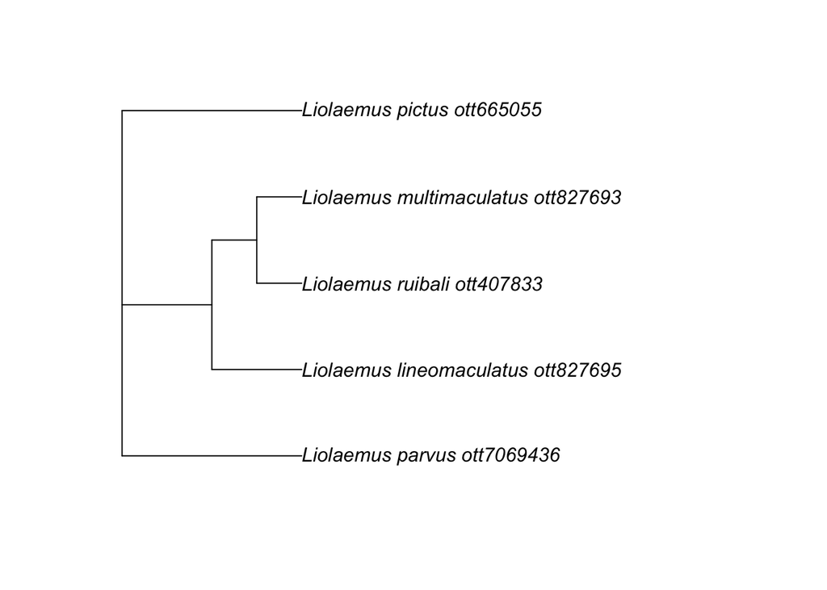

```r
#Compare these two trees:
plot(focal_tree)
```

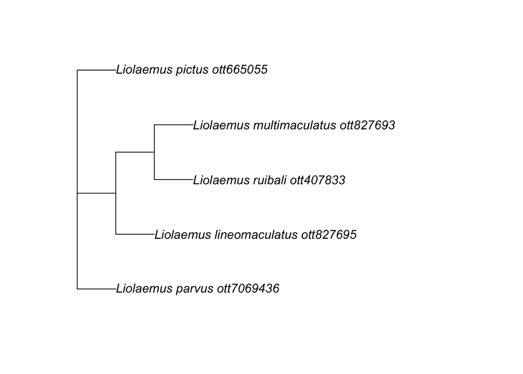

```r
plot(compute.brlen(focal_tree, 1)) #this tree has branch lengths added, you can see that relationships between taxa remain the same
```

```r
#update focal_tree
focal_tree_w_branchs<-compute.brlen(focal_tree, 1)
```

So, that can fix our focal tree, but what about `taxonomy_tree`? Loot at this tree again… there is no nested relationships here… this means that we cannot use it further….

If you did need to use taxonomy, then you would have to pick species that were more distantly related so that the taxonomy would add structure (for instance, each genus would define a “monophyletic” group).

**Coming soon - calculating Blomberg’s K to evaluate evolutionary lability**